# My Reproducible Report

Dean Marengi

2025-01-21

## Overview

This file provides a quick look at how each component of an R Markdown file works together to produce an integrated report.

Remember, R Markdown allows us to:

- **Combine narrative text, code, and output** into a single document
- Incorporate mathematical expressions or equations
- And render/export the .Rmd file to a variety of output file formats!
- The YAML header specified in this `.Rmd` file enables us to render the output to:
  - A Microsoft Word document (`.docx`)
  - A `pdf` file
  - Or `html` file
- **Gapminder dataset/R package:** https://cran.r-project.org/web/packages/gapminder/vignettes/gapminder.html

## Load packages

In this code chunk, we are loading some relevant package libraries. By using the `include = FALSE` in our chunk options, we are telling the `.Rmd` file to exclude the code/output from the exported document.

## Create a plot in the below code chunk

Below we create a faceted figure using the gapminder dataset. We use the chunk options to specify the figure output height and width, as well as to create a figure caption. Notice that we can also use markdown syntax to format the caption text (e.g., **bold face text**)

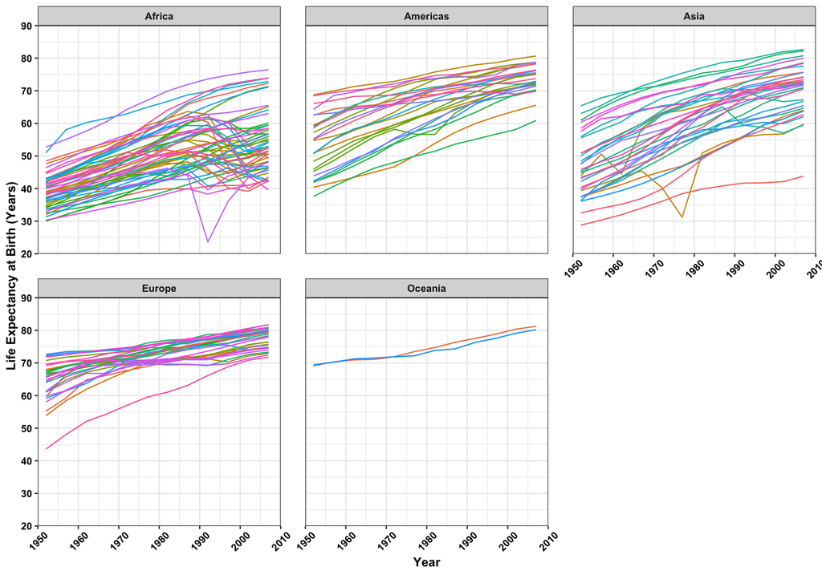

**Life expectancy over time by country, stratified by continent.**

```r
# Create life expectancy by year figure
ggplot(data, aes(x = year, y = lifeExp, color = country)) +
  geom_line(show.legend = FALSE) +
  scale_x_continuous(
    expand = c(0, 0),
    limits = c(1950, 2010),
    breaks = seq(1950, 2010, 10)
  ) +
  scale_y_continuous(
    expand = c(0, 0),
    limits = c(20, 90),
    breaks = seq(20, 90, 10)
  ) +
  labs(x = "Year", y = "Life Expectancy at Birth (Years)") +
  facet_wrap(~ continent) +
  theme_bw() +
  theme(
    axis.text = element_text(face = "bold", color = "black"),
    axis.text.x = element_text(angle = 45, vjust = 0.6),
    axis.title = element_text(face = "bold"),
    strip.text = element_text(face = "bold"),
    panel.spacing.x = unit(1.5, "lines"),
    panel.spacing.y = unit(1.5, "lines")
  )
```

## How to embed a simple table (using the KableExtra package)

Here’s a walkthrough of what each line of code is doing:

- Reshape the `gapminder` dataset so it’s in a long-data format
- Filter for only life expectancy values obtained for the year 2007
- Apply a group structure to the data frame (to compute grouped summary statistics)
- Compute some simple summary statistics by continent
- Round to two decimal places across numeric columns
- Use the Kable package to generate a simple but nicely formatted table

```r
data %>%
  pivot_longer(lifeExp:gdpPercap, names_to = "parameters", values_to = "values") %>%
  filter(year == 2007 & parameters == "lifeExp") %>%
  group_by(continent) %>%
  summarize(Mean = mean(values, na.rm = TRUE),
            `Std. Dev` = sd(values, na.rm = TRUE),
            `Min.`= min(values, na.rm = TRUE),
            `Max.` = max(values, na.rm = TRUE)) %>%
  mutate(across(is.numeric, ~ round(., 2))) %>%
  kbl() %>%
  kable_classic()
```

| continent | Mean | Std. Dev | Min. | Max. |
| --- | --- | --- | --- | --- |
| Africa | 54.81 | 9.63 | 39.61 | 76.44 |
| Americas | 73.61 | 4.44 | 60.92 | 80.65 |
| Asia | 70.73 | 7.96 | 43.83 | 82.60 |
| Europe | 77.65 | 2.98 | 71.78 | 81.76 |
| Oceania | 80.72 | 0.73 | 80.20 | 81.24 |

### Some examples of how you can embed quantitative statements into your file with LaTeX.

- Enclosing the expression in pairs of two dollar signs (`$$`..`$$`) generates a stand-alone equation.
  $$\begin{equation}
  \hat{Y}_i = \hat{\beta}_0 + \hat{\beta}_1 X_i + \hat{\epsilon}_i
  \end{equation}$$
- In contrast, wrapping the expression in a pair of single dollar signs (`$`..`$`) creates an in-line quantitative expression.
- This is some text with an in-line equation like $\hat{Y}_i = \hat{\beta}_0 + \hat{\beta}_1 X_i + \hat{\epsilon}_i$. Pretty cool, right?